# Linkedin Deliverable 3

Jonathan Cheon

10/7/2019

# Final Deliverable

In this study, I was able to look at various Linkedin datasets. Initially, I wanted to discover how beauty would impact a person’s career or salary. Due to complications, my research questions have changed or turned different directions.

This report will improve previous deliverables and provide a final suggestion.

### Importing libraries and previous files

[output not shown]

```
## [1] "part2.r"
```

[output not shown]

## Deliverable 1 Edits

Cleaning up my person tibble where I will be removing all rows where a column has a NA.

```r
# Remove rows where NA is present.
person <- person[!is.na(person$positionLocation),]
person <- person[!is.na(person$ageEstimate),]
person <- person[!is.na(person$genderEstimate),]
person <- person[!is.na(person$companyName),]
person <- person[!is.na(person$country),]
person <- person[!is.na(person$isPremium),]
person <- person[!is.na(person$posTitle),]
person <- person[!is.na(person$positionId),]

#Removing columns I will not need.
linkedin$companyHasLogo <- NULL
linkedin$hasPicture <- NULL
```

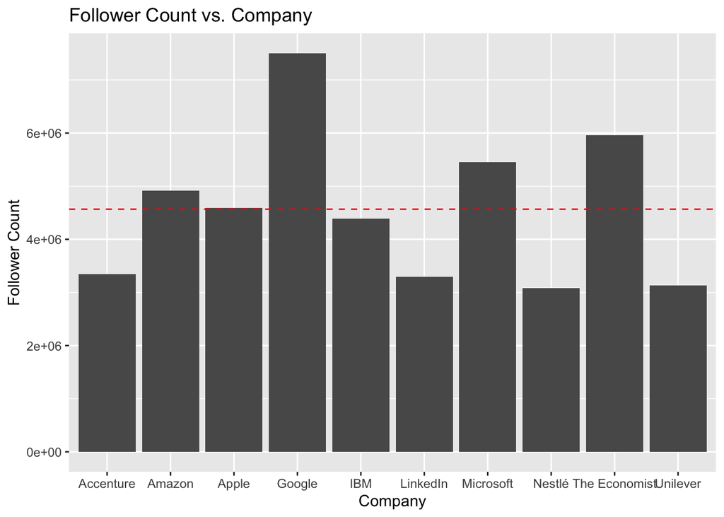

```r
ggplot(x, aes(name, followerCount)) + geom_col() +
  geom_hline(yintercept = mean(x$followerCount), linetype="dashed", color="red") +
  labs(x="Company",y="Follower Count",title="Follower Count vs. Company")
```

## Deliverable 2 imporovement

Here, I will be cleaning more of my dataset from deliverable 2. I want to narrow my search just look at their coorpirate positions. These are the one’s I have seen a lot of while manually looking through the dataset.

```r
#extract only Managers, Director, Assistant, Engineer, ANalyst, Consultant, Coordinator, and Supervisor
scraped$position <- str_extract(scraped$position, "Manager|Director|Assistant|Engineer|Analyst|Consultant|Coordinator|Supervisor")

#remove rows where position row is NA
scraped <- scraped[!is.na(scraped$position),]

#make position column to factor.
levels(scraped$position <- as.factor(scraped$position))
```

```
## [1] "Analyst"     "Assistant"   "Consultant"  "Coordinator" "Director"
## [6] "Engineer"    "Manager"     "Supervisor"
```

```r
#Remove description column
scraped$description <- NULL

#Print first 10 rows.
head(scraped, n = 10L)
```

```
## # A tibble: 10 x 3
##    position    location      pay
##    <fct>       <fct>       <dbl>
##  1 Assistant   Sydney      60000
##  2 Assistant   Sydney      70000
##  3 Manager     Sydney    1300000
##  4 Assistant   Sydney      60000
##  5 Assistant   Sydney      70000
##  6 Manager     Sydney    1300000
##  7 Manager     Sydney      70000
##  8 Coordinator Melbourne   60000
##  9 Analyst     Sydney      50000
## 10 Analyst     Sydney      50000
```

# Hypothesis

After looking at my previous dataset and what I have cleaned, I think I will be able to make a model that would be able to **predict how long a person would stay at their job based on various variables**. Here, I will be cleaning up a little more to pursue this question.

```r
#calculate number of positions and calculate avg pay based on positions.
position_group <- group_by(scraped, position)
avg_pay <- dplyr::summarise(position_group,
  count = n(),
  pay_avg = mean(pay, na.rm = TRUE))

#Creating new tibble where position, number of that position, and average page from scraped data.
avg_pay_tibble <- tibble(posTitle = as.factor(avg_pay$position),
                         count = avg_pay$count,
                         avg_pay = avg_pay$pay_avg)

#Making position title column to a factor.
avg_pay_tibble$posTitle <- as.factor(avg_pay_tibble$posTitle)

#Cleaning linkedin dataset. Grabbing only people where their positions are Manager, Director, Assistant, Engineer, Analyst, Consultant, Coordinator, or Supervisor.
linkedin$posTitle <- str_extract(linkedin$posTitle, "Manager|Director|Assistant|Engineer|Analyst|Consultant|Coordinator|Supervisor")

#Making position title to a factor
linkedin$posTitle <- as.factor(linkedin$posTitle)

#Grabbing the position locations where it matches ACT, Adelide, Brisbane, Melbourne, Perth, and Sydney
linkedin$posLocation <- str_extract(linkedin$posLocation, "ACT|Adelaide|Brisbane|Melbourne|Perth|Sydney")

#Doing a join to combine my calculated average pay by position tibble with the original table called linkedin.
linkedin <- left_join(linkedin, avg_pay_tibble, by= "posTitle")

#Remove all rows where NA exists.
linkedin <- na.omit(linkedin)

#Remove some columns we don't need.
linkedin$mbrLocation <- NULL
linkedin$mbrTitle <- NULL

#Print first 10 rows in linkedin.
# head(linkedin, n=10L)
datatable(linkedin, options=list(pageLength=5))
```

|  | index | ageEstimate | companyFollowerCount | companyName | companyStaffCount | companyUrl | connectionsCount | country | endDate | followable | followersCount | genderEstimate | isPremium | posLocation | posTitle | positionId | startDate | avgMemberPosDuration | avgCompanyPosDuration | count | avg_pay |
| --- | --- | --- | --- | --- | --- | --- | --- | --- | --- | --- | --- | --- | --- | --- | --- | --- | --- | --- | --- | --- | --- |
| 43 | 42 | 48 | 13694 | Grant Thornton Australia | 1255 | http://www.grantthornton.com.au | 500 | au | 2012-06-01 | 1 | 4247 | male | 1 | Sydney | Director | 33198 | 2010-11-01 | 1052.9 | 849.8281 | 3 | 163126 |
| 44 | 43 | 48 | 1660685 | PwC | 235683 | http://www.pwc.com | 500 | au | 2010-11-01 | 1 | 4247 | male | 1 | Sydney | Consultant | 33199 | 2005-02-01 | 1052.9 | 1214.539 | 31 | 60855.8064516129 |
| 46 | 45 | 48 | 31923 | King &amp; Wood Mallesons | 3494 | http://www.kwm.com | 500 | au | 2003-02-01 | 1 | 4247 | male | 1 | Sydney | Manager | 33201 | 1999-12-01 | 1052.9 | 1002.4695 | 71 | 128617.352112676 |
| 47 | 46 | 48 | 198859 | Commonwealth Bank | 32905 | http://www.commbank.com.au/ | 500 | au | 1999-11-01 | 1 | 4247 | male | 1 | Sydney | Manager | 33202 | 1998-01-01 | 1052.9 | 989.9361 | 71 | 128617.352112676 |
| 48 | 47 | 48 | 795604 | KPMG | 180604 | http://www.kpmg.com | 500 | au | 1998-12-01 | 1 | 4247 | male | 1 | Sydney | Consultant | 33203 | 1996-01-01 | 1052.9 | 837.6367 | 31 | 60855.8064516129 |
| 49 | 48 | 48 | 6004 | Cuscal Limited | 425 | http://cuscalpayments.com.au | 500 | au | 1996-12-01 | 1 | 4247 | male | 1 | Sydney | Consultant | 33204 | 1995-01-01 | 1052.9 | 954.8404 | 31 | 60855.8064516129 |
| 67 | 66 | 22 | 85260 | General Assembly | 2901 | http://www.generalassemb.ly | 136 | au | 2016-09-01 | 1 | 137 | male | 0 | Melbourne | Engineer | 26999 | 2016-06-01 | 92 | 185.8841 | 8 | 93271.875 |
| 69 | 68 | 37 | 6842 | Dialog Information Technology | 1168 | https://www.dialog.com.au | 371 | au | 2013-02-01 | 1 | 372 | male | 0 | Brisbane | Consultant | 60939 | 2011-07-01 | 833 | 893.9694 | 31 | 60855.8064516129 |
| 73 | 72 | 28 | 1361 | Biarri | 40 | http://www.biarri.com | 359 | au | 2018-12-01 | 1 | 358 | male | 1 | Brisbane | Consultant | 263047 | 2016-08-01 | 440.75 | 725.2174 | 31 | 60855.8064516129 |
| 74 | 73 | 28 | 814 | Console Connect | 8 | https://www.consoleconnect.com | 359 | au | 2016-07-01 | 1 | 358 | male | 1 | Brisbane | Engineer | 263048 | 2016-02-01 | 440.75 | 563.1613 | 8 | 93271.875 |

[output cut: 6354 more lines]

# Analysis

For my first analysis, I will be attempting to predict how long a person would stay at their job based on their age, size of company, connection count on Linkedin, follower count on Linkedin, gender, average pay, and by what position. Let’s begin.

```r
#Randomly choosing 70% of the data.
sample_selection <- createDataPartition(linkedin$avgMemberPosDuration, p=0.70, list=FALSE)

#Splitting up 70% to go into our train. and 30% to go into our test.
train = linkedin[sample_selection, ]
test = linkedin[-sample_selection, ]

# Linear model on average member position duration vs. age, company size, linkedin connections, linkedin followers, gender, average pay, and groups of positions.
train_model <- lm(avgMemberPosDuration ~ ageEstimate + companyStaffCount + connectionsCount + followersCount + genderEstimate + avg_pay +  factor(posTitle), data = train)

summary(train_model)
```

```
##
## Call:
## lm(formula = avgMemberPosDuration ~ ageEstimate + companyStaffCount +
##     connectionsCount + followersCount + genderEstimate + avg_pay +
##     factor(posTitle), data = train)
##
## Residuals:
##     Min      1Q  Median      3Q     Max
## -1094.6  -260.8   -81.5   163.3  6839.0
##
## Coefficients: (1 not defined because of singularities)
##                               Estimate Std. Error t value Pr(>|t|)
## (Intercept)                  6.047e+02  1.640e+02   3.688 0.000229 ***
## ageEstimate                  1.619e+01  7.720e-01  20.970  < 2e-16 ***
## companyStaffCount            6.063e-05  8.598e-05   0.705 0.480710
## connectionsCount            -3.629e-01  6.668e-02  -5.441 5.57e-08 ***
## followersCount               7.808e-03  3.839e-03   2.034 0.042058 *
## genderEstimatemale           1.085e+01  1.505e+01   0.721 0.470808
## avg_pay                     -3.403e-03  1.348e-03  -2.524 0.011626 *
## factor(posTitle)Assistant   -1.966e+02  8.002e+01  -2.457 0.014053 *
## factor(posTitle)Consultant  -9.583e+01  8.100e+01  -1.183 0.236831
## factor(posTitle)Coordinator -1.965e+02  8.640e+01  -2.275 0.022958 *
## factor(posTitle)Director     3.889e+02  6.783e+01   5.734 1.05e-08 ***
## factor(posTitle)Engineer     5.123e+01  4.251e+01   1.205 0.228221
## factor(posTitle)Manager      1.961e+02  2.656e+01   7.386 1.80e-13 ***
## factor(posTitle)Supervisor          NA         NA      NA       NA
## ---
## Signif. codes:  0 '***' 0.001 '**' 0.01 '*' 0.05 '.' 0.1 ' ' 1
##
## Residual standard error: 441.9 on 4443 degrees of freedom
## Multiple R-squared:  0.1474, Adjusted R-squared:  0.1451
## F-statistic: 64.03 on 12 and 4443 DF,  p-value: < 2.2e-16
```

```r
predictions <- train_model %>% predict(test)
```

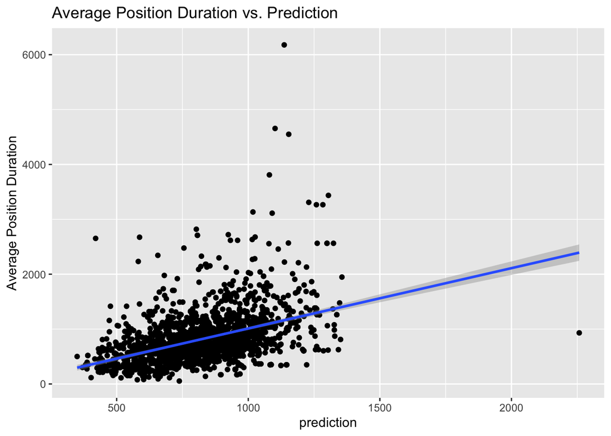

```r
#Let's plot it
ggplot(data = test, aes(x = predictions, y = avgMemberPosDuration)) + geom_jitter() +
  labs(x="prediction",y="Average Position Duration",title="Average Position Duration vs. Prediction") +
  geom_smooth(method="lm")
```

```r
R2 <- R2(predictions, test$avgMemberPosDuration)
RMSE <- RMSE(predictions, test$avgMemberPosDuration)
MAE <- MAE(predictions, test$avgMemberPosDuration)

R2
```

```
## [1] 0.1848223
```

```r
RMSE
```

```
## [1] 434.7011
```

```r
MAE
```

```
## [1] 291.3305
```

Looks like there are some strong indicators that would be helpful to predict how long a person will stay at a company. According to the summary, it says age, linkedin connections count, average pay, assistant positions, coordinator positions, and director positions have significant p-values. Because we see that the Director’s position is of significant values, we will need to create a new column to determine if a position is of Director. Then we will include that column into the independent variables to try to make a more accurate estimate of how long a person would stay at their job.

```r
#creates a vector to see if a person's position is a Director type.
director_bool <- grepl("Director", linkedin$posTitle)

#append this column to our original dataset in linkedin.
linkedin$director_bool <- director_bool

#Randomly choosing 70% of the data.
sample_selection <- createDataPartition(linkedin$avgMemberPosDuration, p=0.70, list=FALSE)

#Splitting up 70% to go into our train. and 30% to go into our test.
train = linkedin[sample_selection, ]
test = linkedin[-sample_selection, ]

#New train models with all the significant variables from pervious model and with our new director boolean variable.
train_model <- lm(avgMemberPosDuration ~ ageEstimate + connectionsCount + avg_pay + director_bool, data = train)

summary(train_model)
```

```
##
## Call:
## lm(formula = avgMemberPosDuration ~ ageEstimate + connectionsCount +
##     avg_pay + director_bool, data = train)
##
## Residuals:
##     Min      1Q  Median      3Q     Max
## -1171.4  -260.3   -85.7   160.2  6861.1
##
## Coefficients:
##                     Estimate Std. Error t value Pr(>|t|)
## (Intercept)        1.456e+02  4.210e+01   3.459 0.000547 ***
## ageEstimate        1.738e+01  7.475e-01  23.250  < 2e-16 ***
## connectionsCount  -2.992e-01  6.497e-02  -4.605 4.24e-06 ***
## avg_pay            9.622e-04  2.554e-04   3.767 0.000167 ***
## director_boolTRUE  1.209e+02  2.601e+01   4.646 3.48e-06 ***
## ---
## Signif. codes:  0 '***' 0.001 '**' 0.01 '*' 0.05 '.' 0.1 ' ' 1
##
## Residual standard error: 450.3 on 4451 degrees of freedom
## Multiple R-squared:  0.1442, Adjusted R-squared:  0.1434
## F-statistic: 187.4 on 4 and 4451 DF,  p-value: < 2.2e-16
```

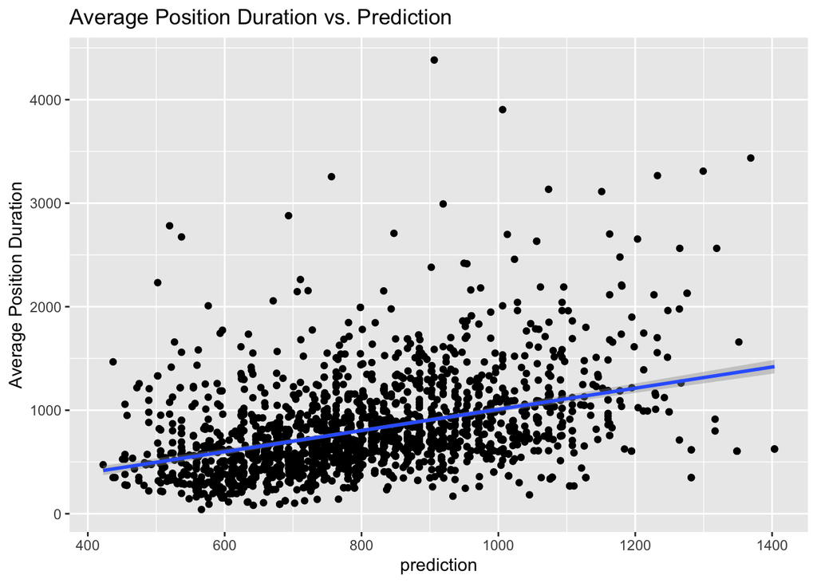

```r
predictions <- train_model %>% predict(test)

#Let's plot it
ggplot(data = test, aes(x = predictions, y = avgMemberPosDuration)) +
  geom_jitter() +
  geom_smooth(method="lm") +
  labs(x="prediction",y="Average Position Duration",title="Average Position Duration vs. Prediction")
```

```r
R2 <- R2(predictions, test$avgMemberPosDuration)
RMSE <- RMSE(predictions, test$avgMemberPosDuration)
MAE <- MAE(predictions, test$avgMemberPosDuration)

R2
```

```
## [1] 0.1557291
```

```r
RMSE
```

```
## [1] 423.0751
```

```r
MAE
```

```
## [1] 297.8397
```

# Operationalize

I believe that this would be an okay model for HR representatives to look at when they are trying to hire a new director. Depending on how long they want a director to stay at their job, they would need to at least look at their pay, age, and see if they are currently a director. For connections count, this doesn’t really make sense. It could be very possible that the director moved jobs various time which would mean that the person meet new people more often. Since these variables only count for 15% of the predictions, we also need to look further into this to see if there are other indicators to predict how long a person would stay being a director.

Some unintended consequences that might arise from using this data approach to predict how long a director would stay at their position is that once a good model is made, HR representatives could adjust their compensation to make a director stay longer at their company. This could also go the other way as well. For example, if a director is not performing at their peak levels, they would adjust some of the variables to make a director leave their jobs. We would not be entirely sure which way it would sway, but these are just precautionary suggestions.